# R Notebook

# VARIABLES CONTINUAS

Se pueden caracterizar totalmente por su función de riesgo $h(t)$. Veamos a contunación las siguientes familias.

# Exponencial

Carecterizamos las exponenciales, sea $\lambda = 0.5$

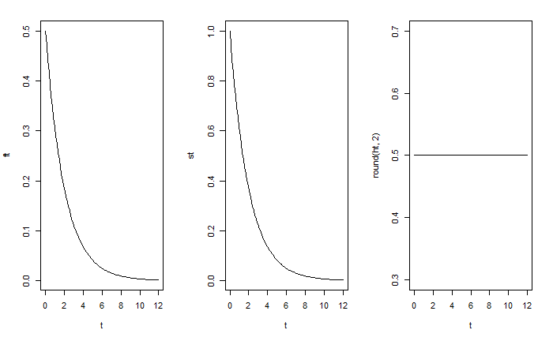

# Weibull

Familia Weibull. Una fdd con $\alpha = 0.5$ y $\lambda = 1$.

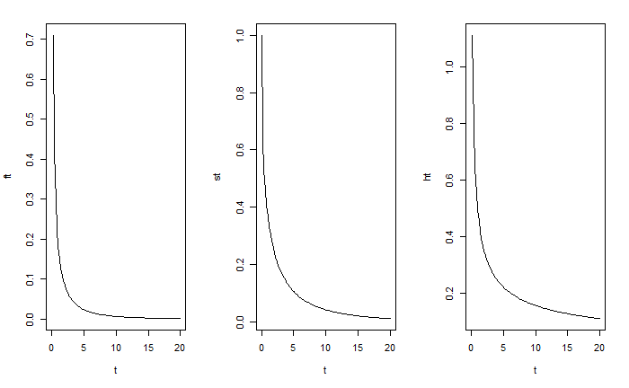

Modificando los valores para $\alpha , \lambda$, se muestran las siguientes funciones.

### $\alpha$ fija

Veamos como se cruzan las funciones de supervivencia para $\alpha_{0}$ fija y con $\lambda$ variante. Sea $\alpha_{0} = 0.5$

#### Gráficas individuales

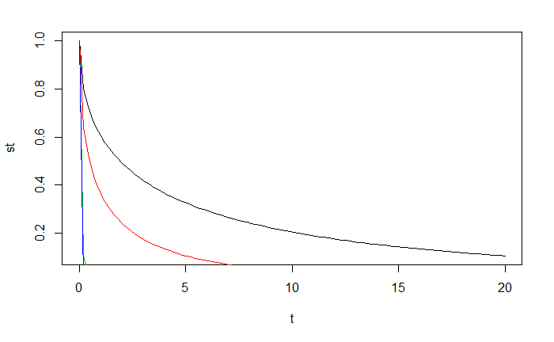

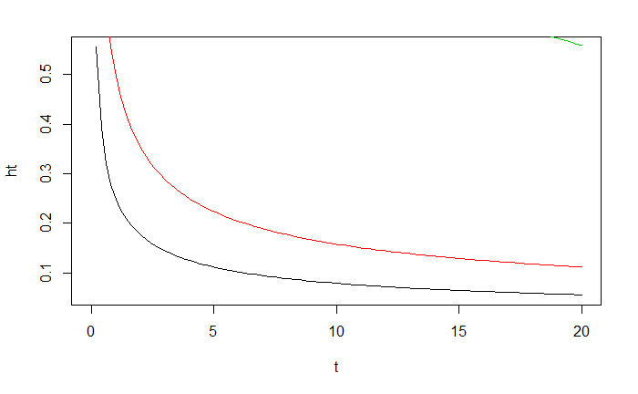

#### Gráficas conjuntas

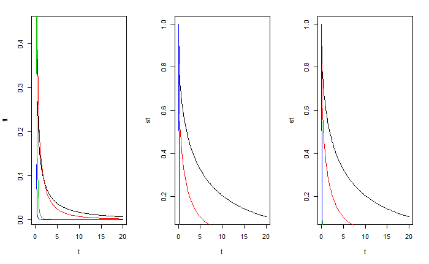

### $\lambda$ fija

Veamos como se cruzan las funciones de supervivencia para $\lambda{0}$ fija y con $\alpha$ variante. Sea $\lambda_{0} = 1$

#### Gráficas individuales

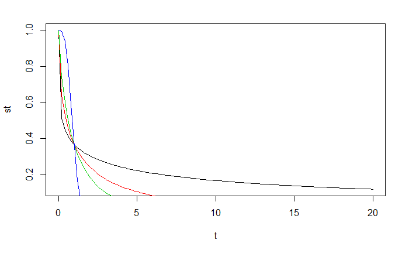

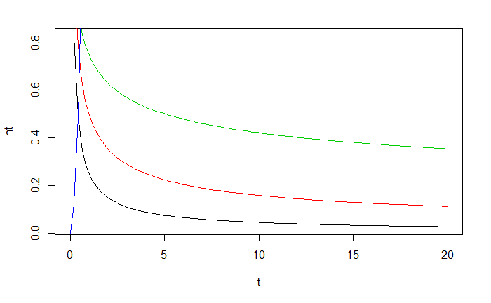

Viendolo de manera conjunta

#### Gráficas conjuntas

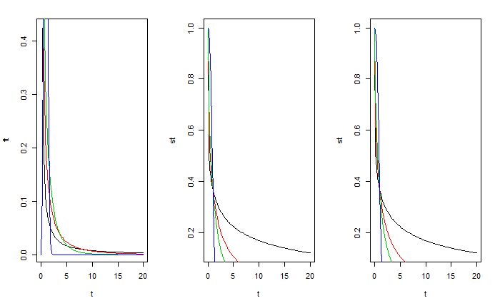

# Lognormal

# Gamma

Notas:

- Si $\alpha < 1$ entonces $h(t)$ es decreciente.
- Si $\alpha > 1$ entonces $h(t)$ es creciente.
- Si $\alpha = 1$ entonces $h(t)$ es cte. (caso exponencial)

# Loglogistic

# Generalized gamma

**Notas**:

- Caso $\alpha = \beta = 1$: Es una *exponencial*.
- Caso $\beta = 1$: Es una *weibull*.
- Caso $\alpha = 1$: Es una *gamma*.
- Caso $\beta \to \infty$: Una *lognormal*.

### Caso cualquiera

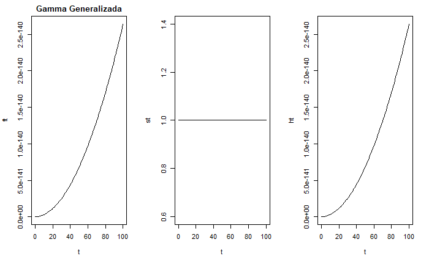

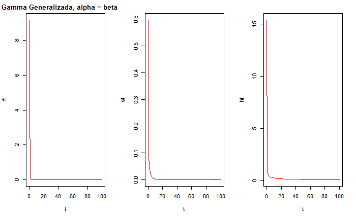

### Caso weibull

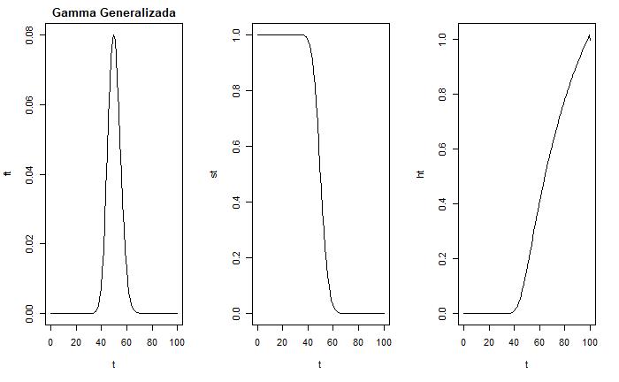